# Reddit Markov Chain

## Markov Chains and Text Mining on Reddit Subreddits

#### NLP and HMMs

Datalytics with Alicja

Team Project. Full code on main github page

1. Overview
2. Data
3. Data Preprocessing
4. NLP
5. Markov Chain

### Overview:

- data collected from Reddit.com
- data was scraped using PRAW and BeautifulSoup
- NLP using nltk package
- dashboard developed using Dash and Flask

### Data

Data was scraped from Reddit using PRAW package.

- there are currently around 1.2 MM subreddits established
- focused narrowed down to 1000 top post titles
- extracted two seperate files:
  - top subreddits
  - top posts

### *scrape.py*:

```python
def scrape_top_subreddits(url, limit):
    data = []
    for i in range(1, 100):
        response = requests.get(url + "/?page={}".format(i))
        content = BeautifulSoup(response.content, "html.parser")
        for c in content.find_all("div", attrs={"class": "span4 listing"}):
            if "Subscribers" == c.find("h3", attrs={"class": "listing-header"}).text:
                results = c.find_all(
                    "div", attrs={"data-target-filter": "sfw", "class": "listing-item"})
                for r in results:
                    data.append(r.get("data-target-subreddit"))
                    if len(data) == limit:
                        return pd.DataFrame({"subreddits": data})
    return None


def scrape_subreddit_data(reddit, subreddits):
    data = []
    for subr in subreddits:
        sub = reddit.subreddit(subr).top(limit=1000)
        data.extend([{"subreddit": subr, "id": s.id, "title": s.title,
                      "gilded": s.gilded, "score": s.score} for s in sub])
        print("Finished scraping r/{}".format(subr))
    return pd.DataFrame(data)


if __name__ == "__main__":
    reddit = praw.Reddit(client_id='JRRDQWr5Mn_8LA', client_secret='gmhoQTNiZhEp4hj08q7s_lb7Is0',
                         user_agent='Comment Extraction by /u/ivanchen9520')
    # STEP 1: get the top subreddits
    subreddits = scrape_top_subreddits("http://www.redditlist.com", 50)
    # STEP 2: get top posts from subreddits
    data = scrape_subreddit_data(reddit, subreddits.subreddits)
    # save dataframes
    subreddits.to_csv("data/subs.csv", index=False)
    data.to_csv("data/posts.csv", index=False)
```

### Data Preprocessing

- removed hyperlinks
- replaced contractions (can't to cannot etc.)
- removed punctuations using regex
- tokenized text data

```python
def decontract(phrase):
    # helper function to remove contractions
    phrase = re.sub(r"won\'t", "will not", phrase)
    phrase = re.sub(r"can\'t", "can not", phrase)
    phrase = re.sub(r"n\'t", " not", phrase)
    phrase = re.sub(r"\'re", " are", phrase)
    phrase = re.sub(r"\'s", " is", phrase)
    phrase = re.sub(r"\'d", " would", phrase)
    phrase = re.sub(r"\'ll", " will", phrase)
    phrase = re.sub(r"\'t", " not", phrase)
    phrase = re.sub(r"\'ve", " have", phrase)
    phrase = re.sub(r"\'m", " am", phrase)
    return phrase


def create_prob_matrices(subreddit, data):
    start_m = defaultdict(int)
    prob_m_1 = defaultdict(lambda: defaultdict(int))
    prob_m_2 = defaultdict(lambda: defaultdict(int))

	# limit to 1000 comments for faster runtimes
    for title in data[data.subreddit == subreddit].title:
		    # preprocessing
		    text = re.sub(r"http\S+", "", str(title)) # first remove hyperlinks
		    text = decontract(text) # second convert contractions into orginal phrases
		    text = text.translate(str.maketrans("", "", string.punctuation)) # remove punctuations

		    # tokenization
		    words = nltk.word_tokenize(text)
		    words = [word.lower() for word in words if word.isalpha()]

		    # structuring
		    if len(words) >= 2:
		        start_m["{}:{}".format(words[0], words[1])] += 1
		        for i in range(len(words)):
		            if i < len(words) - 1:
		                prob_m_1[words[i]][words[i+1]] += 1
		            if i < len(words) - 2:
		                prob_m_2["{}:{}".format(words[i], words[i+1])][words[i+2]] += 1
    return (start_m, prob_m_1, prob_m_2)

if __name__ == "__main__":
    data = pd.read_csv("data/posts.csv")
    for subs in list(data.subreddit.unique()):
        s, one, two = create_prob_matrices(subs, data)
        ## save dictionaries to json
        with open("data/start/{}.json".format(subs), "w") as out:
            json.dump(s, out)
        with open("data/one/{}.json".format(subs), "w") as out:
            json.dump(one, out)
        with open("data/two/{}.json".format(subs), "w") as out:
            json.dump(two, out)
        print("Finished creating matrices for r/{}".format(subs))
```

### NLP

#### Wordclouds

- created wordclouds through package wordclouds in python
- show trending words per subreddit

Example below: Subreddit *Movies*

```python
if __name__ == "__main__":
    posts = pd.read_csv("data/posts.csv")
    titles = posts.groupby("subreddit")["title"].apply(lambda x: " ".join(x))

    for i,t in enumerate(titles):
        wordcloud = WordCloud(font_path="fonts/GoogleSans-Medium.ttf", background_color="white", colormap="ocean",
                            width=1000, height=400, max_words=400).generate(t)
        wordcloud.to_file(f"wordclouds/{titles.index[i]}.png")
```

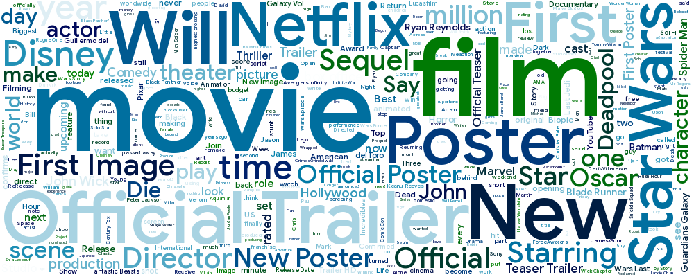

### Markov Chains

- mathematical system that experiences transitions from one state to another
- usage: Speech Recognition, Financial Modeling, Pattern Recognition
- satisfies Markov Property: make predictions about the future based on current state
- for text generator we implemented back-off feature
  - prevents from spitting out text that's too similar(overfitting)
- created two matrices : 1-1 transition and 2-1 transition

Example: subreddit *Food*

```python
def read_json_matrix(root, subreddit):
    result = {}
    for i in ["start", "one", "two"]:
        filepath = os.path.join(root, "data/{}/{}.json".format(i, subreddit))
        with open(filepath) as infile:
            result[i] = json.load(infile)
    return result

def convert_json_matrix(start, one, two):
    start_df = pd.DataFrame(list(start.items()), columns=["word", "count"])
    one_ngram_df = pd.DataFrame(one).fillna(0)
    two_ngram_df = pd.DataFrame(two).fillna(0)

    #divide by column sum
    start_df["prob"] = start_df["count"]/start_df["count"].sum(axis=0)
    one_ngram_df = one_ngram_df.divide(one_ngram_df.sum(axis=0))
    two_ngram_df = two_ngram_df.divide(two_ngram_df.sum(axis=0))
    return (start_df, one_ngram_df, two_ngram_df)

def generate_sentence(start_df, one_ngram_df, two_ngram_df, threshold, limit):
    curr = np.random.choice(start_df.word, 1, p=start_df.prob)[0]
    final_sentence = " ".join(curr.split(":"))
    while True:
        if len(final_sentence.split(" ")) == limit:
            break
        poss_vals = two_ngram_df.get(curr)
        if (poss_vals is None) or (len(poss_vals[poss_vals != 0]) <= threshold):
            curr_keyword = curr.split(":")[1]
            if curr_keyword not in list(one_ngram_df):
                break
            next_word = np.random.choice(list(one_ngram_df[curr_keyword].index), 1, p=one_ngram_df[curr_keyword].values)[0]
            final_sentence += " {}".format(next_word)
            curr = "{}:{}".format(curr_keyword, next_word)
        else:
            next_word = np.random.choice(list(two_ngram_df[curr].index), 1, p=two_ngram_df[curr].values)[0]
            final_sentence += " {}".format(next_word)
            curr = "{}:{}".format(curr.split(":")[1], next_word)
    return final_sentence
```

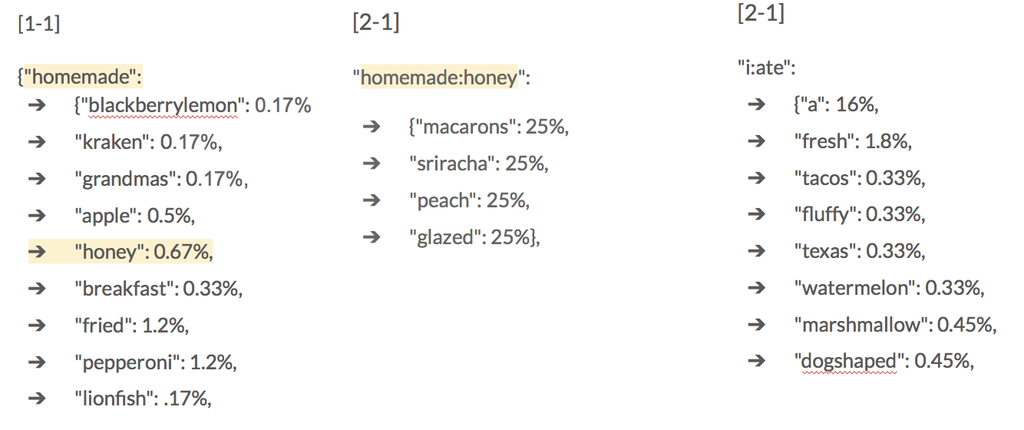

### CONCLUSION

This project was an attempt to explore one of the most popular and opinionated websites there is on the internet. From web scraping of the most popular subreddits and posts within those subreddits, through text mining of the most frequent words and phrases to generating and predicting possible text outputs of a given subreddit topic using Markov Chains. Markov Chains is used widely and we manipulated the process by implementing the “back-off” method to make our results as accurate as possible and as interesting as possible.

The entire project and steps were combined into one web application that created a dashboard of text mining outputs(WordClouds) as well as sentences produced via using Markov Chains model. This project allowed us to interactively and successfully apply text mining techniques on our dataset. Markov Chains can be applied by online businesses like Reddit to be able to maximize the accuracy of the pop up window that generates “the most likely word” when using a search tool on their website. Maximizing effectiveness of drop down menus makes the experience for the end user more valuable. The nicer the experience the longer the user will stay on the website.

Keywords and phrases can be used as a tool to help understand relationships and trends on the website, they can also help to segment users into different clusters based on their responses which in turn can bring profits if those users are targeted effectively. Peoples comments or posts reflect the emotion they feel about certain topics, which can be a gold mine of information if used properly. Patterns can be recognized and influenced. There is so much companies can do when analyzing heavy text data sets and use the results to better the company’s marketing efforts especially when analyzing people’s emotions - the previously thought of as more of an intangible measure.